# Comparing False Discovery Proportion (FDP) Methods

Author

Michael Heming

Published

January 4, 2026

# Introduction

This document compares three different methods for controlling the False Discovery Rate (FDR) or False Discovery Proportion (FDP) in multiple hypothesis testing using simulated quantitative omics data:

1. **Benjamini-Hochberg (BH)**: The classic FDR control procedure
2. **q-value (Storey)**: An improved FDR estimation method
3. **permFDP**: A permutation-based approach for controlling FDP

The simulation uses a realistic model where biological variability determines which features are truly null.

# Setup

```r
library(qvalue)
library(permFDP)
library(knitr)

set.seed(123)
```

# Simulation Function

Based on the SIMPLYCORRECT realistic model with default parameters: - m = 800 features - nc = 10 controls, nt = 10 treatment samples - effectSD = 1 (typical effect magnitude) - bioVar = 0.05 (typical biological variability) - bioVGamma = c(4, 0.5) - expVar = 0.03 (technical variability)

```r
simulate_realistic_data <- function(seed = 1) {

    set.seed(seed)

    m <- 800
    avg <- 22
    sd <- 3
    nc <- 10
    nt <- 10
    effectSD <- 1
    bioVar <- 0.05
    bioVGamma <- c(4, 0.5)
    expVar <- 0.03

    trueQuantC <- rnorm(m, avg, sd)

    realEffects <- rnorm(m, 0, effectSD)

    bioVars <- rgamma(m, shape = bioVGamma[1], scale = bioVGamma[2]) *
               bioVar / (bioVGamma[1] * bioVGamma[2])

    nullIsTrue <- (abs(realEffects) < (bioVars * trueQuantC))
    realEffects[nullIsTrue] <- 0

    design_vector <- c(rep(1, nc), rep(2, nt))
    expr_data <- matrix(0, nrow = m, ncol = nc + nt)

    for (i in 1:m) {
        totalVar <- trueQuantC[i] * bioVars[i] + trueQuantC[i] * expVar
        expr_data[i, 1:nc] <- rnorm(nc, trueQuantC[i], totalVar)
        expr_data[i, (nc+1):(nc+nt)] <- rnorm(nt, trueQuantC[i] + realEffects[i], totalVar)
    }

    pvalues <- sapply(1:m, function(i) {
        t.test(expr_data[i, 1:nc], expr_data[i, (nc+1):(nc+nt)])$p.value
    })

    list(
        expr_data = expr_data,
        design_vector = design_vector,
        pvalues = pvalues,
        nullIsTrue = nullIsTrue,
        n_true_null = sum(nullIsTrue),
        n_true_sig = sum(!nullIsTrue)
    )
}
```

# Run Three Independent Simulations

To ensure robustness, we run the same realistic model three times with different random seeds.

```r
n_simulations <- 3

simulated_data <- lapply(1:n_simulations, function(i) {
    simulate_realistic_data(seed = 100 + i)
})

names(simulated_data) <- paste("Simulation", 1:n_simulations)

for (name in names(simulated_data)) {
    cat(name, ":\n", sep = "")
    cat("  True nulls:", simulated_data[[name]]$n_true_null, "\n")
    cat("  True signals:", simulated_data[[name]]$n_true_sig, "\n\n")
}
```

```
Simulation 1:
  True nulls: 511
  True signals: 289

Simulation 2:
  True nulls: 519
  True signals: 281

Simulation 3:
  True nulls: 517
  True signals: 283
```

# Apply Methods to Each Simulation

```r
results_list <- list()

for (sim_name in names(simulated_data)) {
    cat("\n===", sim_name, "===\n")

    sim <- simulated_data[[sim_name]]
    pvals <- sim$pvalues

    padj_bh <- p.adjust(pvals, method = "BH")
    sign_bh <- which(padj_bh <= 0.05)

    qobj <- qvalue(p = pvals, fdr.level = 0.05)
    sign_qv <- which(qobj$qvalues <= 0.05)

    set.seed(123)
    pf_threshold <- permFDP::permFDP.adjust.threshold(
        pVals = pvals,
        threshold = 0.05,
        myDesign = sim$design_vector,
        intOnly = sim$expr_data,
        nPerms = 100
    )
    sign_pf <- which(pvals <= pf_threshold)

    cat("BH:", length(sign_bh), "| Qvalue:", length(sign_qv),
        "| permFDP:", length(sign_pf), "\n")

    calc_stats <- function(sign_idx, true_null, n_null, n_sig) {
        R <- length(sign_idx)
        if (R == 0) {
            return(c(R = 0, TP = 0, FP = 0, FDP = 0, Sensitivity = 0, Specificity = 1))
        }

        TP <- sum(!true_null[sign_idx])
        FP <- sum(true_null[sign_idx])
        TN <- n_null - FP

        c(R = R, TP = TP, FP = FP, FDP = FP / R,
          Sensitivity = TP / n_sig, Specificity = TN / n_null)
    }

    results_list[[sim_name]] <- list(
        BH = calc_stats(sign_bh, sim$nullIsTrue, sim$n_true_null, sim$n_true_sig),
        Qvalue = calc_stats(sign_qv, sim$nullIsTrue, sim$n_true_null, sim$n_true_sig),
        permFDP = calc_stats(sign_pf, sim$nullIsTrue, sim$n_true_null, sim$n_true_sig),
        true_null_count = sim$n_true_null,
        true_sig_count = sim$n_true_sig
    )
}
```

```
=== Simulation 1 ===
BH: 78 | Qvalue: 92 | permFDP: 92

=== Simulation 2 ===
BH: 46 | Qvalue: 66 | permFDP: 56

=== Simulation 3 ===
BH: 67 | Qvalue: 74 | permFDP: 69
```

# Results

```r
extract_method_results <- function(method_name) {
    do.call(rbind, lapply(results_list, function(x) x[[method_name]]))
}

bh_results <- extract_method_results("BH")
qv_results <- extract_method_results("Qvalue")
pf_results <- extract_method_results("permFDP")

rownames(bh_results) <- names(results_list)
rownames(qv_results) <- names(results_list)
rownames(pf_results) <- names(results_list)

bh_avg <- colMeans(bh_results)
qv_avg <- colMeans(qv_results)
pf_avg <- colMeans(pf_results)
```

## Individual Simulation Results

### Benjamini-Hochberg (BH)

```r
kable(bh_results, digits = 4, caption = "BH Performance Across Simulations")
```

BH Performance Across Simulations

|  | R | TP | FP | FDP | Sensitivity | Specificity |
| --- | --- | --- | --- | --- | --- | --- |
| Simulation 1 | 78 | 76 | 2 | 0.0256 | 0.2630 | 0.9961 |
| Simulation 2 | 46 | 44 | 2 | 0.0435 | 0.1566 | 0.9961 |
| Simulation 3 | 67 | 67 | 0 | 0.0000 | 0.2367 | 1.0000 |

### Q-value (Storey)

```r
kable(qv_results, digits = 4, caption = "Q-value Performance Across Simulations")
```

Q-value Performance Across Simulations

|  | R | TP | FP | FDP | Sensitivity | Specificity |
| --- | --- | --- | --- | --- | --- | --- |
| Simulation 1 | 92 | 88 | 4 | 0.0435 | 0.3045 | 0.9922 |
| Simulation 2 | 66 | 63 | 3 | 0.0455 | 0.2242 | 0.9942 |
| Simulation 3 | 74 | 73 | 1 | 0.0135 | 0.2580 | 0.9981 |

### permFDP

```r
kable(pf_results, digits = 4, caption = "permFDP Performance Across Simulations")
```

permFDP Performance Across Simulations

|  | R | TP | FP | FDP | Sensitivity | Specificity |
| --- | --- | --- | --- | --- | --- | --- |
| Simulation 1 | 92 | 88 | 4 | 0.0435 | 0.3045 | 0.9922 |
| Simulation 2 | 56 | 54 | 2 | 0.0357 | 0.1922 | 0.9961 |
| Simulation 3 | 69 | 69 | 0 | 0.0000 | 0.2438 | 1.0000 |

## Average Performance

```r
avg_results <- rbind(
    BH = bh_avg,
    Qvalue = qv_avg,
    permFDP = pf_avg
)

kable(avg_results, digits = 4, caption = "Average Performance Across 3 Simulations")
```

Average Performance Across 3 Simulations

|  | R | TP | FP | FDP | Sensitivity | Specificity |
| --- | --- | --- | --- | --- | --- | --- |
| BH | 63.6667 | 62.3333 | 1.3333 | 0.0230 | 0.2188 | 0.9974 |
| Qvalue | 77.3333 | 74.6667 | 2.6667 | 0.0341 | 0.2622 | 0.9948 |
| permFDP | 72.3333 | 70.3333 | 2.0000 | 0.0264 | 0.2468 | 0.9961 |

## Comparison by Simulation

```r
for (sim_name in names(results_list)) {
    cat("\n###", sim_name, "\n\n")
    cat("True nulls:", results_list[[sim_name]]$true_null_count,
        "| True signals:", results_list[[sim_name]]$true_sig_count, "\n\n")

    sim_results <- rbind(
        BH = bh_results[sim_name, ],
        Qvalue = qv_results[sim_name, ],
        permFDP = pf_results[sim_name, ]
    )
    print(kable(sim_results, digits = 4))
    cat("\n")
}
```

### Simulation 1

True nulls: 511 | True signals: 289

|  | R | TP | FP | FDP | Sensitivity | Specificity |
| --- | --- | --- | --- | --- | --- | --- |
| BH | 78 | 76 | 2 | 0.0256 | 0.2630 | 0.9961 |
| Qvalue | 92 | 88 | 4 | 0.0435 | 0.3045 | 0.9922 |
| permFDP | 92 | 88 | 4 | 0.0435 | 0.3045 | 0.9922 |

### Simulation 2

True nulls: 519 | True signals: 281

|  | R | TP | FP | FDP | Sensitivity | Specificity |
| --- | --- | --- | --- | --- | --- | --- |
| BH | 46 | 44 | 2 | 0.0435 | 0.1566 | 0.9961 |
| Qvalue | 66 | 63 | 3 | 0.0455 | 0.2242 | 0.9942 |
| permFDP | 56 | 54 | 2 | 0.0357 | 0.1922 | 0.9961 |

### Simulation 3

True nulls: 517 | True signals: 283

|  | R | TP | FP | FDP | Sensitivity | Specificity |
| --- | --- | --- | --- | --- | --- | --- |
| BH | 67 | 67 | 0 | 0.0000 | 0.2367 | 1.0000 |
| Qvalue | 74 | 73 | 1 | 0.0135 | 0.2580 | 0.9981 |
| permFDP | 69 | 69 | 0 | 0.0000 | 0.2438 | 1.0000 |

# Visual Comparison

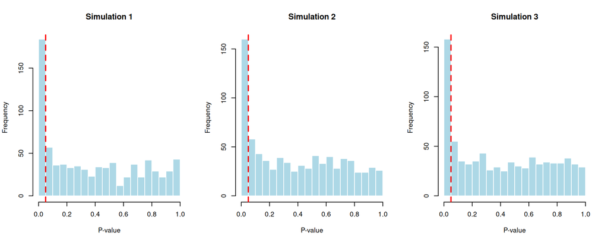

```r
par(mfrow = c(1, 3))

for (sim_name in names(simulated_data)) {
    sim <- simulated_data[[sim_name]]
    hist(sim$pvalues, breaks = 30, main = sim_name,
         xlab = "P-value", col = "lightblue", border = "white")
    abline(v = 0.05, col = "red", lty = 2, lwd = 2)
}
```

## Key Metrics Explained

- **R**: Total number of rejections (discoveries)
- **TP**: True Positives (correctly identified signals)
- **FP**: False Positives (incorrectly identified signals)
- **FDP**: False Discovery Proportion (FP/R) - should be ≤ 0.05
- **Sensitivity**: Power to detect true signals (TP/total signals)
- **Specificity**: Ability to avoid false positives (TN/total nulls)